# UPF Daily Intake

## Data Access

You can find this dataset at: https://sldr.netlify.app/data/upf_daily_intake.csv.

## Context

This data is from a paper by Kevin Hall and colleagues, titled [“Ultra-Processed Diets Cause Excess Calorie Intake and Weight Gain: An Inpatient Randomized Controlled Trial of Ad Libitum Food Intake.”](https://doi.org/10.1016/j.cmet.2019.05.008). (The data collected in the study are shared publicly at https://osf.io/rx6vm/ as a series of SAS files, and this dataset is a version of the data that has been prepared for you to use in R.)

The authors summarize their work this way:

> > The perpetual diet wars between factions promoting low-carbohydrate, keto, paleo, high-protein, low-fat, plant-based, vegan, and a seemingly endless list of other diets have led to substantial public confusion and mistrust in nutrition science. While debate rages about the relative merits and demerits of various so-called healthy diets, less attention is paid to the fact that otherwise diverse diet recommendations often share a common piece of advice: avoid ultra-processed foods (Katz and Meller, 2014). Ultra-processed foods have been described as “formulations mostly of cheap industrial sources of dietary energy and nutrients plus additives, using a series of processes” and containing minimal whole foods (Monteiro et al., 2018)…Increased availability and consumption of ultra-processed foods have been associated with rising obesity prevalence, but scientists have not yet demonstrated that ultra-processed food causes obesity or adverse health outcomes. Researchers at the NIH investigated whether people ate more calories when exposed to a diet composed of ultra-processed foods compared with a diet composed of unprocessed foods… Subjects were admitted to the NIH Clinical Center and randomized to receive either ultra-processed or unprocessed diets for 2 weeks immediately followed by the alternate diet for 2 weeks… Despite the ultra-processed and unprocessed diets being matched for daily presented calories, sugar, fat, fiber, and macronutrients, people consumed more calories when exposed to the ultra-processed diet as compared to the unprocessed diet. Furthermore, people gained weight on the ultra-processed diet and lost weight on the unprocessed diet. Limiting consumption of ultra-processed food may be an effective strategy for obesity prevention and treatment.

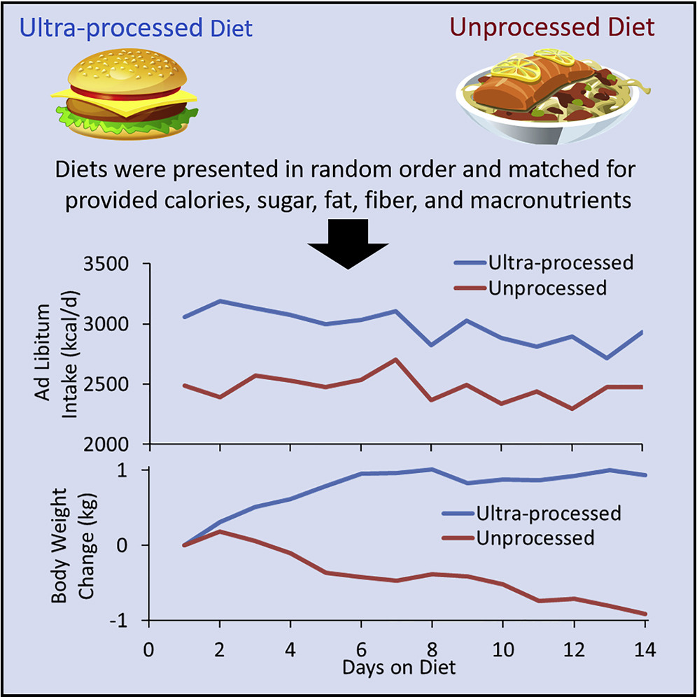

## Metadata

This dataset has one row of data per person, per day of the study. Variables reported in the dataset include:

- `subject_id`, a unique identifier for each of the 20 study participants
- person’s `height` in meters
- person’s `sex` (recorded values are “Male” or “Female”)
- person’s `age` in years
- `date` of data collection
- `day_in_study`: number of days since the start of the study
- `day_in_diet`: number of days since the person started eating their current diet (either “Unprocessed” or “Ultra-processed” foods)
- `diet`: whether the person was eating “Unprocessed” or “Ultra-processed” food on this day
- `water` and `drinking_water`: different measures of the amount of water consumed on this day. (Sorry I don’t know the difference between them.)
- `food_mass` consumed on this day
- `energy_intake` on this day in kcal (calories)
- `protein_intake` on this day in kcal (calories)
- `fat_intake` on this day in kcal (calories)
- `carb_intake`: carbohydrate intake on this day in kcal (calories)
- `sugar_intake` on this day in kcal (calories)
- `fiber_intake` on this day in grams
- `sodium_intake` on this day in milligrams